# Spotify top 100 zenei listák elemzése

Január 10, 2020

## Az elemzés alapjai

- A spotify 2017-18-as top 100-as listájának adatait elemezzük, mely a rangsorolt dalok számtalan zenei jellemzőjét rögzíti (ezek rövid leírása később).
- Azt szeretnénk megmagyarázni, hogy van-e összefüggés ezen jellemzők és a toplistán elfoglalt helyezés között.
- Ezen kívül egy másik alternatív módszerünk, hogy megpróbáljuk leírni, hogy milyen paraméterekkel rendelkező dal kerülhet a toplistára.

## Adattisztítás

- Egyes változókat kiszedtünk, mert teljesen irreleváns volt a szerepltetésük (és az értelmük)

```r
top_2017[, c("id", "time_signature", "key", "mode"):=NULL]
top_2018[, c("id", "time_signature", "key", "mode"):=NULL]
```

## Változók jelentése

- danceability
- energy
- loudness
- spechiness
- acousticness
- instrumentalness
- valence
- tempo
- duration_ms

## Évek összehasonlítása

- Az évek összehasonlítása néhány változó szerint azt mutatja, hogy nem különböznek igazán ezek az évek zenei stílusban.

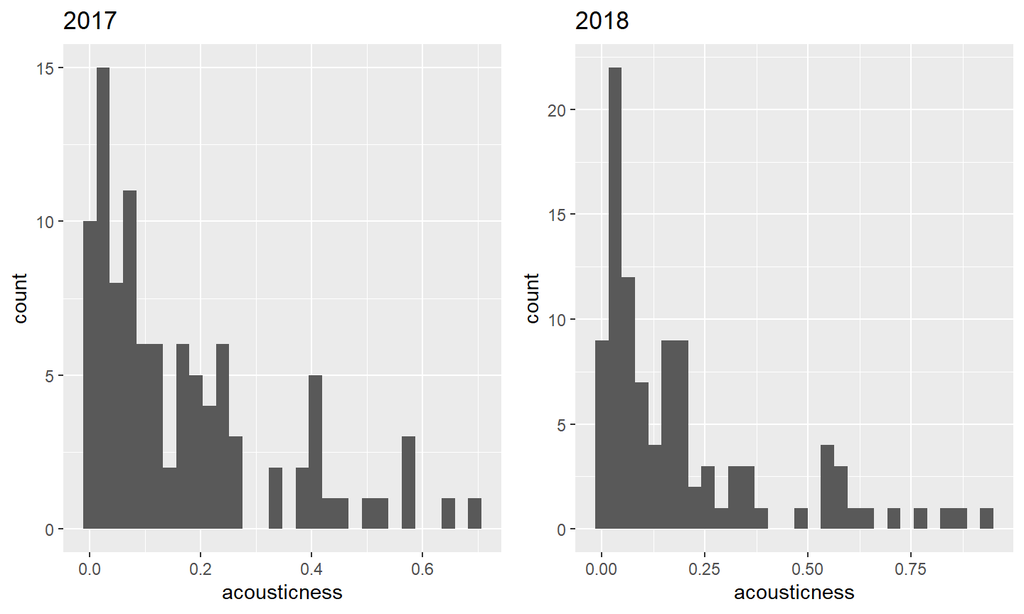

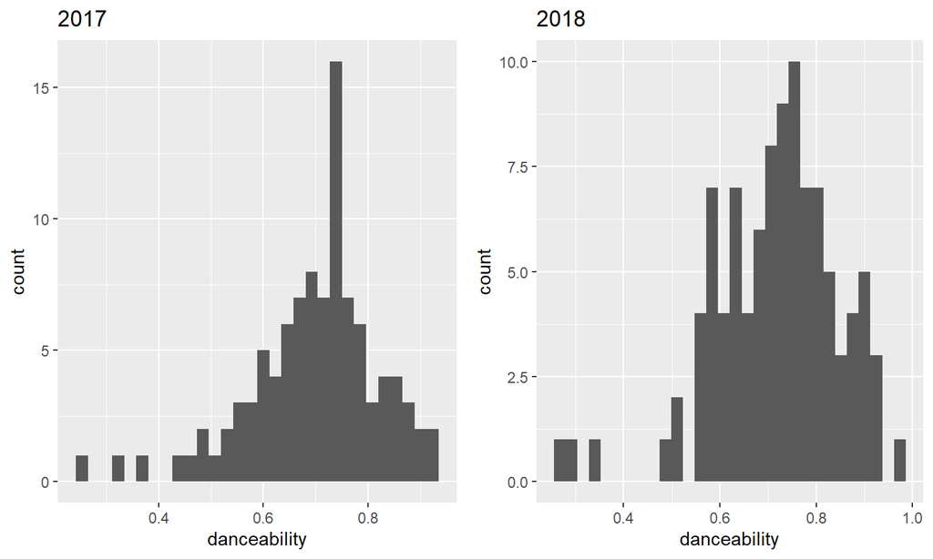

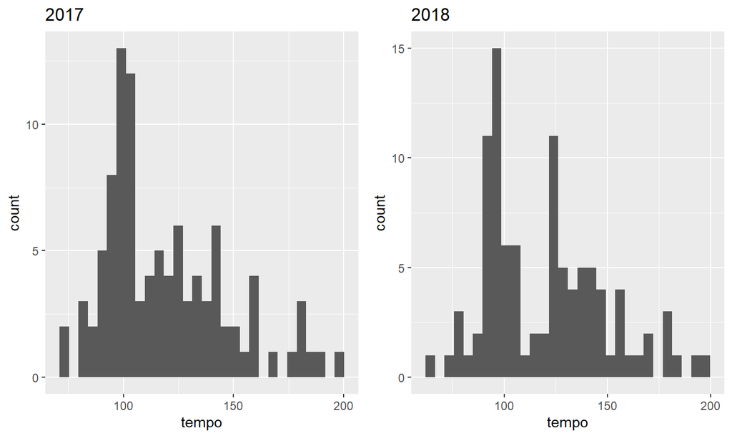

## Adattisztítás vol. 2

-Néhány dal mindkét év toplistáján szerepelt, ezektől megtisztítottuk az adatokat

```r
top100_unique <- unique(top100_music_dt, by = "name")
```

## Néhány kezdeti ábra, summary

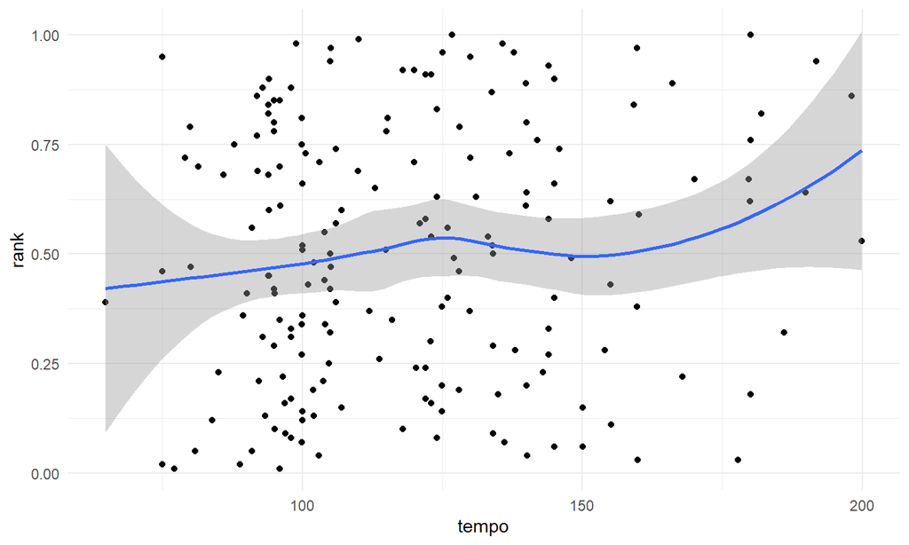

## Summary(top100_unique)

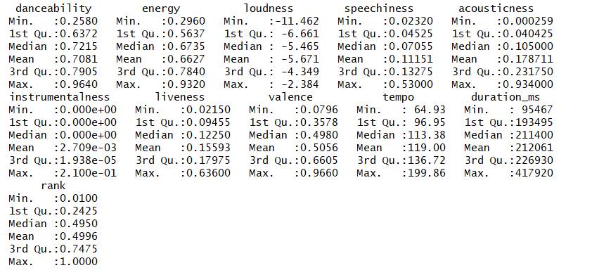

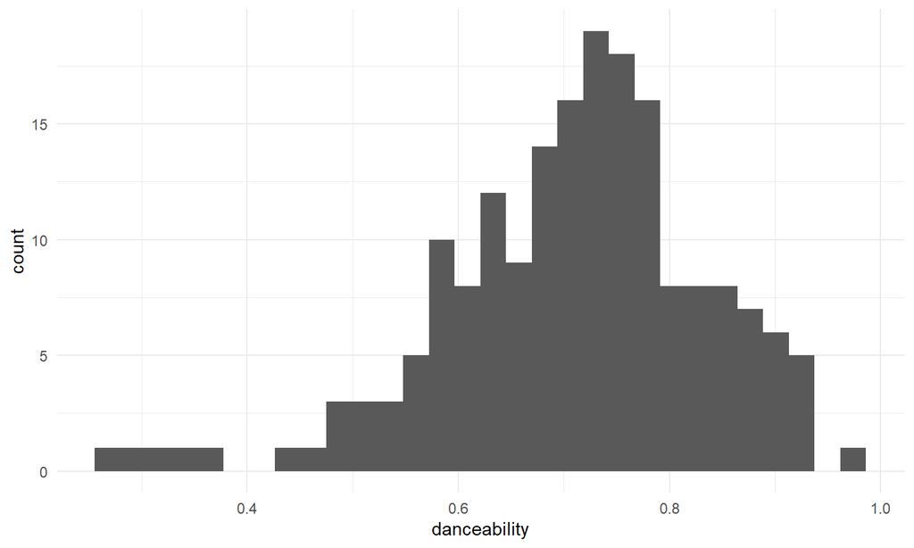

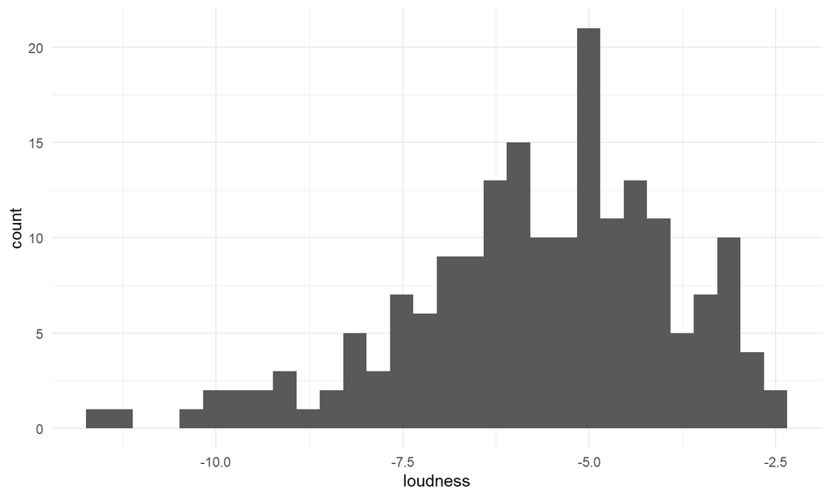

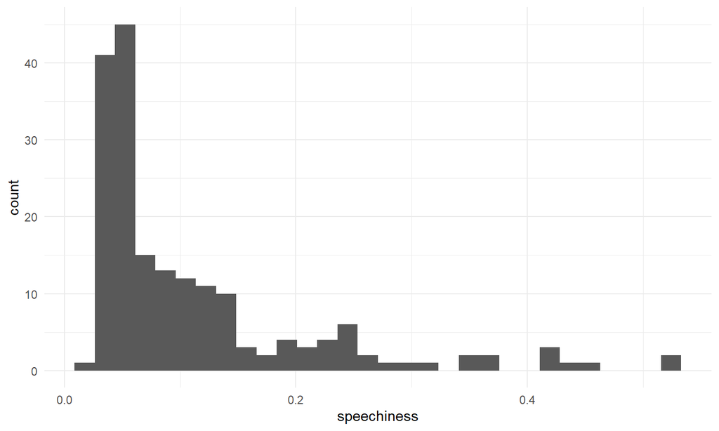

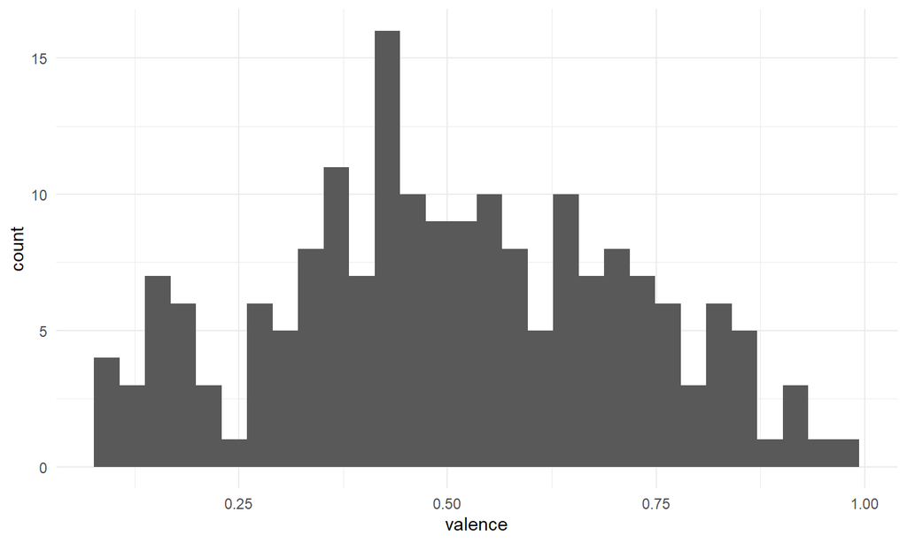

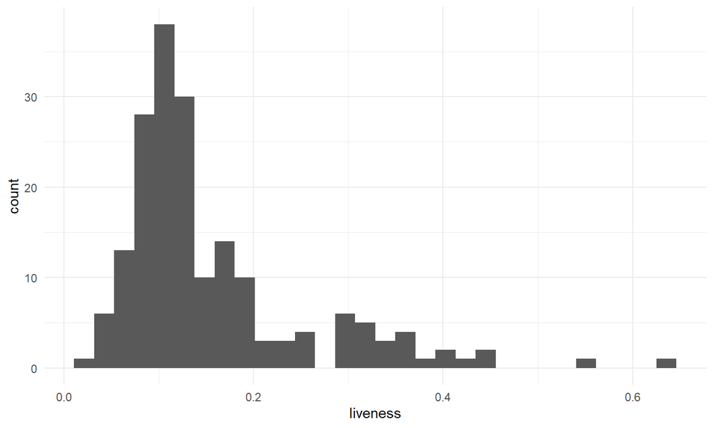

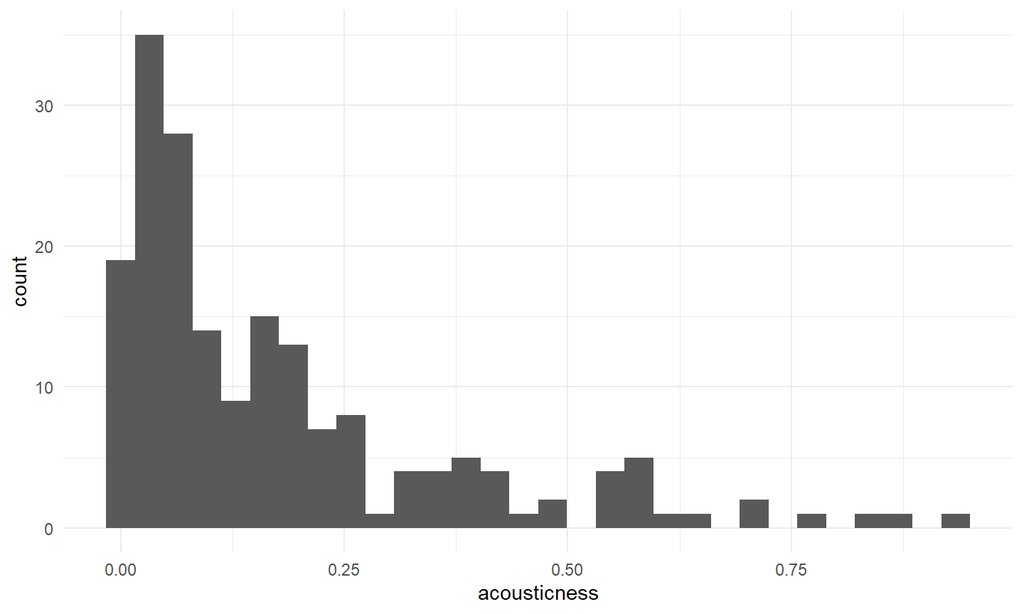

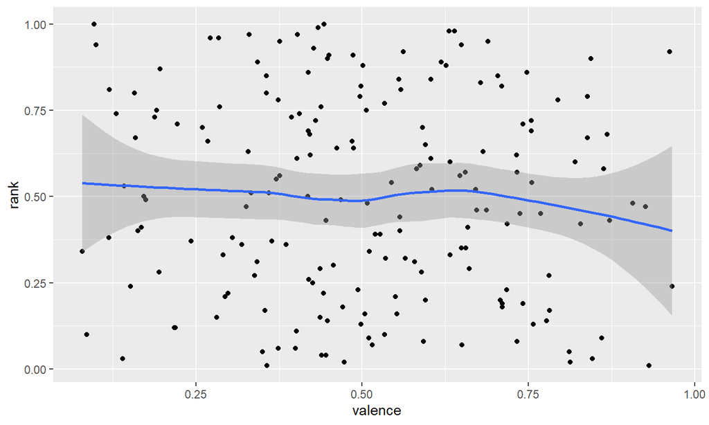

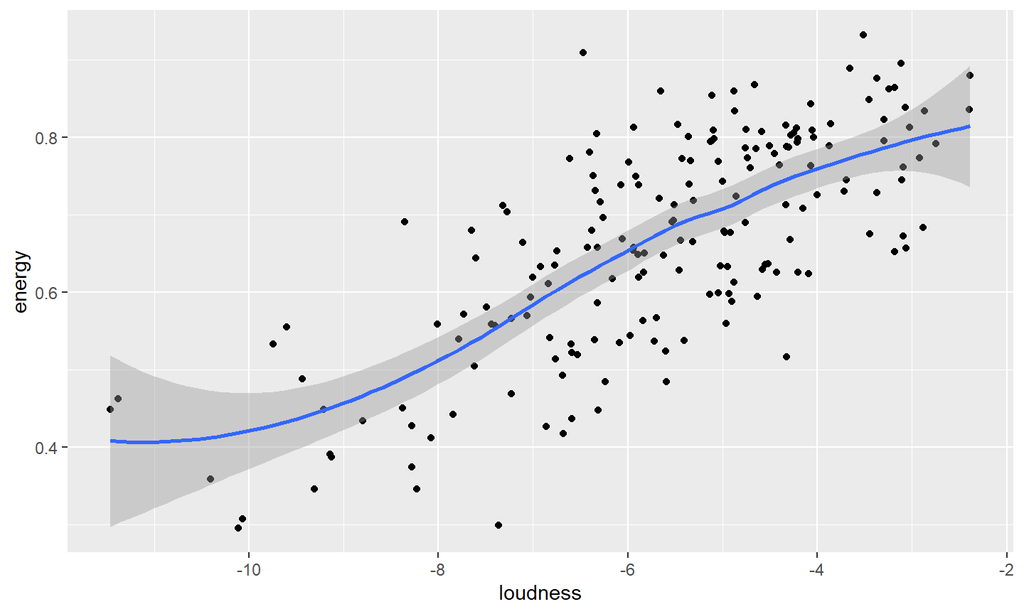

## Korrelációs mátrix

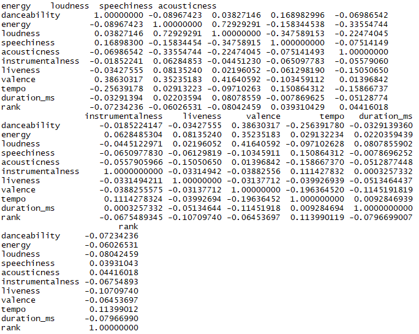

-Mint látható a korrelációs mátrixból és az ábrákból, a rank igazán semmivel sem korrelál, egyes más változók egymással viszont elég erősen.Ennek ellenére érdemesnek tartjuk továbbvinni ezt az elméletet és regressziót futtatni.

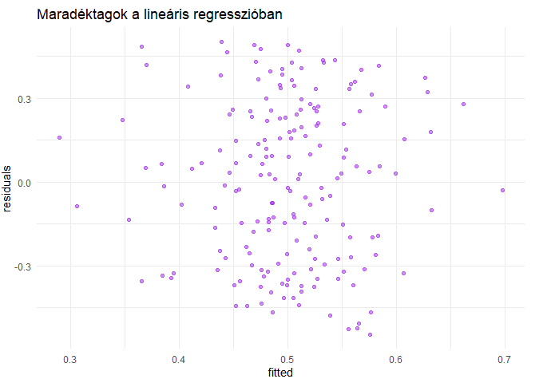

- A maradéktagokat mutató ábra alapján az elmondható, hogy azok randomok, így nem maradt ki szisztematikus hatás.

## Summary (lm1)

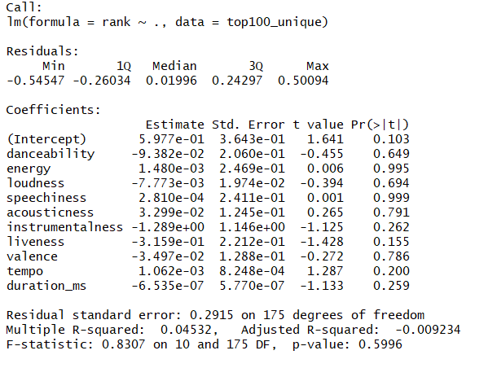

- Ellenben a p (és t) értékekből látszik, hogy a modellünk egyik magyarázó változója sem szignifikáns (ami a korrelációs mátrixból sejthető volt)

## Summary (lm2)

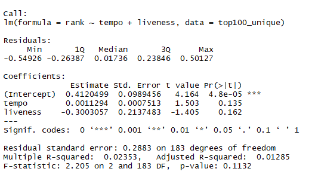

- Az új lineáris regresszióban benne hagytuk a teljes modellből (lm1) a két legkisebb p-értékű tagot, azonban ezek p-értéke és így szignifikanciája nem változott. A rank ezzel a két változóval korrelált leginkább kezdetben.
- Interakció hozzáadásának nem láttuk értelmét (nincs értelme ezen változók kombinálásának), viszont az egyértelmű, hogy a modellnek nincs magyarázóereje.
- (Természetesen előfordulhat, hogy meglévő változókon kívül igazából teljesen más tényezők magyarázzák a toplistás helyezést (ízlés, előadó hírneve, divat, előadóval kapcsolatos hírek és történések stb.).)

## Logit regresszió

```
Call:
glm(formula = rank ~ acousticness + danceability + loudness +
    speechiness + liveness, family = "binomial", data = top100_unique)

Deviance Residuals:
     Min        1Q    Median        3Q       Max
-1.11246  -0.54401   0.03446   0.49430   1.12220

Coefficients:
             Estimate Std. Error z value Pr(>|z|)
(Intercept)   0.42315    1.03751   0.408    0.683
acousticness  0.06232    0.80451   0.077    0.938
danceability -0.72004    1.20669  -0.597    0.551
loudness     -0.04190    0.09123  -0.459    0.646
speechiness   0.28050    1.60769   0.174    0.861
liveness     -1.25034    1.52990  -0.817    0.414

(Dispersion parameter for binomial family taken to be 1)

    Null deviance: 72.249  on 185  degrees of freedom
Residual deviance: 70.779  on 180  degrees of freedom
AIC: 266.79

Number of Fisher Scoring iterations: 3
```

## Logit regresszió

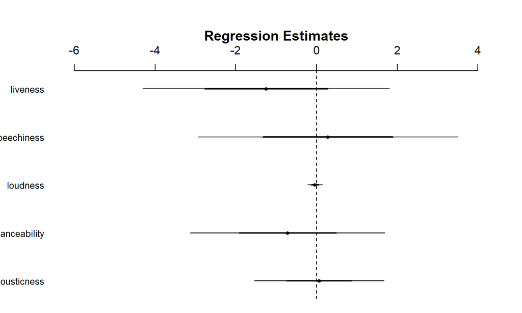

- A logit regresszió is teljesen inszignifikáns modellt ad, így azt gondoljuk, hogy cross-validationnek nincs értelme (nem lehet trainelni az adatot, mert nincs értelmes modell). Helyette visszatérnénk a leíró értelmezéshez.

## Átlagok eltérése

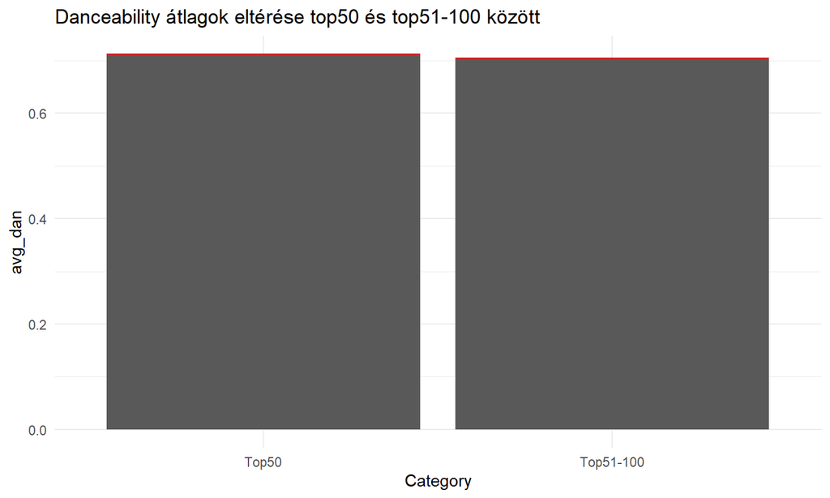